# How Can a Wellness Technology Company Play It Smart

Yuliia Fedirko

28.04.2022

# About case-study

**Bellabeat** is well-being company with smart devices for women. Company is interested to gain insight into how people are already using their smart devices.

**Structure of report:**

1.A clear summary of the business task

2.A description of all data sources used

3.Documentation of any cleaning or manipulation of data

4.A summary of analysis

6.High-level recommendations based on analysis

#### 1.A clear summary of the business task

1. What are some trends in smart device usage?
2. How could these trends apply to Bellabeat customers?
3. How could these trends help influence Bellabeat marketing strategy?

#### 3.Documentation of any cleaning or manipulation of data

```r
#load packages

library(tidyverse)
library(readr)
library(dplyr)
library(lubridate)
library(skimr)
library(janitor)
library(cluster)
library(scales)

#set local settings
Sys.setlocale("LC_ALL","English")
```

```
## [1] "LC_COLLATE=English_United States.1252;LC_CTYPE=English_United States.1252;LC_MONETARY=English_United States.1252;LC_NUMERIC=C;LC_TIME=English_United States.1252"
```

After investigating csv files, we decided to use dailyActivity table as it includes information about steps, calories and intensities; also it`s important to check hourly data about this parameters and sleep. We decided not to use weight data as it contains only 8 distinct values.

```r
#load data from csv file into dataframe
daily_activity <- read_csv("./fitbit_fitness_tracker_data/dailyActivity_merged.csv")
hourly_calories <- read_csv("./fitbit_fitness_tracker_data/hourlyCalories_merged.csv")
hourly_intensities <- read_csv("./fitbit_fitness_tracker_data/hourlyIntensities_merged.csv")
hourly_steps <- read_csv("./fitbit_fitness_tracker_data/hourlySteps_merged.csv")
sleep_day <- read_csv("./fitbit_fitness_tracker_data/sleepDay_merged.csv")
```

```r
#inspecting data
glimpse(daily_activity)
```

```
## Rows: 940
## Columns: 15
## $ Id                       <dbl> 1503960366, 1503960366, 1503960366, 150396036~
## $ ActivityDate             <chr> "4/12/2016", "4/13/2016", "4/14/2016", "4/15/~
## $ TotalSteps               <dbl> 13162, 10735, 10460, 9762, 12669, 9705, 13019~
## $ TotalDistance            <dbl> 8.50, 6.97, 6.74, 6.28, 8.16, 6.48, 8.59, 9.8~
## $ TrackerDistance          <dbl> 8.50, 6.97, 6.74, 6.28, 8.16, 6.48, 8.59, 9.8~
## $ LoggedActivitiesDistance <dbl> 0, 0, 0, 0, 0, 0, 0, 0, 0, 0, 0, 0, 0, 0, 0, ~
## $ VeryActiveDistance       <dbl> 1.88, 1.57, 2.44, 2.14, 2.71, 3.19, 3.25, 3.5~
## $ ModeratelyActiveDistance <dbl> 0.55, 0.69, 0.40, 1.26, 0.41, 0.78, 0.64, 1.3~
## $ LightActiveDistance      <dbl> 6.06, 4.71, 3.91, 2.83, 5.04, 2.51, 4.71, 5.0~
## $ SedentaryActiveDistance  <dbl> 0, 0, 0, 0, 0, 0, 0, 0, 0, 0, 0, 0, 0, 0, 0, ~
## $ VeryActiveMinutes        <dbl> 25, 21, 30, 29, 36, 38, 42, 50, 28, 19, 66, 4~
## $ FairlyActiveMinutes      <dbl> 13, 19, 11, 34, 10, 20, 16, 31, 12, 8, 27, 21~
## $ LightlyActiveMinutes     <dbl> 328, 217, 181, 209, 221, 164, 233, 264, 205, ~
## $ SedentaryMinutes         <dbl> 728, 776, 1218, 726, 773, 539, 1149, 775, 818~
## $ Calories                 <dbl> 1985, 1797, 1776, 1745, 1863, 1728, 1921, 203~
```

```r
glimpse(hourly_calories)
```

```
## Rows: 22,099
## Columns: 3
## $ Id           <dbl> 1503960366, 1503960366, 1503960366, 1503960366, 150396036~
## $ ActivityHour <chr> "4/12/2016 12:00:00 AM", "4/12/2016 1:00:00 AM", "4/12/20~
## $ Calories     <dbl> 81, 61, 59, 47, 48, 48, 48, 47, 68, 141, 99, 76, 73, 66, ~
```

```r
glimpse(hourly_intensities)
```

```
## Rows: 22,099
## Columns: 4
## $ Id               <dbl> 1503960366, 1503960366, 1503960366, 1503960366, 15039~
## $ ActivityHour     <chr> "4/12/2016 12:00:00 AM", "4/12/2016 1:00:00 AM", "4/1~
## $ TotalIntensity   <dbl> 20, 8, 7, 0, 0, 0, 0, 0, 13, 30, 29, 12, 11, 6, 36, 5~
## $ AverageIntensity <dbl> 0.333333, 0.133333, 0.116667, 0.000000, 0.000000, 0.0~
```

```r
glimpse(hourly_steps)
```

```
## Rows: 22,099
## Columns: 3
## $ Id           <dbl> 1503960366, 1503960366, 1503960366, 1503960366, 150396036~
## $ ActivityHour <chr> "4/12/2016 12:00:00 AM", "4/12/2016 1:00:00 AM", "4/12/20~
## $ StepTotal    <dbl> 373, 160, 151, 0, 0, 0, 0, 0, 250, 1864, 676, 360, 253, 2~
```

```r
glimpse(sleep_day)
```

```
## Rows: 413
## Columns: 5
## $ Id                 <dbl> 1503960366, 1503960366, 1503960366, 1503960366, 150~
## $ SleepDay           <chr> "4/12/2016 12:00:00 AM", "4/13/2016 12:00:00 AM", "~
## $ TotalSleepRecords  <dbl> 1, 2, 1, 2, 1, 1, 1, 1, 1, 1, 1, 1, 1, 1, 1, 1, 1, ~
## $ TotalMinutesAsleep <dbl> 327, 384, 412, 340, 700, 304, 360, 325, 361, 430, 2~
## $ TotalTimeInBed     <dbl> 346, 407, 442, 367, 712, 320, 377, 364, 384, 449, 3~
```

All dataframe has id, lets check unique participant and date in each table.

```r
attribute <- c("aily_activity$Id", "hourly_calories$Id","hourly_calories$ActivityHour","hourly_intensities$Id",
"hourly_intensities$ActivityHour","hourly_steps$Id","hourly_steps$ActivityHour",
"sleep_day$Id")

distinct_count <- c(n_distinct(daily_activity$Id),
n_distinct(hourly_calories$Id),
n_distinct(hourly_calories$ActivityHour),
n_distinct(hourly_intensities$Id),
n_distinct(hourly_intensities$ActivityHour),
n_distinct(hourly_steps$Id),
n_distinct(hourly_steps$ActivityHour),
n_distinct(sleep_day$Id))

data.frame(attribute, distinct_count)
```

```
##                         attribute distinct_count
## 1                aily_activity$Id             33
## 2              hourly_calories$Id             33
## 3    hourly_calories$ActivityHour            736
## 4           hourly_intensities$Id             33
## 5 hourly_intensities$ActivityHour            736
## 6                 hourly_steps$Id             33
## 7       hourly_steps$ActivityHour            736
## 8                    sleep_day$Id             24
```

As we see we have: 33 unique participants in the steps, calories and intensities datasets. 24 unique participants in the sleep dataset.

We will divide our research into three logical groups - daily activity, hourly and sleep data. We will merge data from sleep and total activity together. And we will merge hourly data based on id and datetime value.

But before we should do cleaning:

1. check for duplicates
2. check for nulls
3. check for appropriate column names
4. check for types (char to datetime/date)

```r
#clean column names
daily_activity <- clean_names(daily_activity)
hourly_intensities <- clean_names(hourly_intensities)
hourly_calories <- clean_names(hourly_calories)
hourly_steps <- clean_names(hourly_steps)
sleep_day <- clean_names(sleep_day)
```

```r
#check for duplicates
attributes <- c(
"daily_activity",
"hourly_intensities",
"hourly_calories",
"hourly_steps",
"sleep_day")

before <- c(
sum(duplicated(daily_activity)),
sum(duplicated(hourly_intensities)),
sum(duplicated(hourly_calories)),
sum(duplicated(hourly_steps)),
sum(duplicated(sleep_day)))

#remove duplicates
sleep_day <- unique(sleep_day)

after <- c(
sum(duplicated(daily_activity)),
sum(duplicated(hourly_intensities)),
sum(duplicated(hourly_calories)),
sum(duplicated(hourly_steps)),
sum(duplicated(sleep_day)))

data.frame(attributes, before,after)
```

```
##           attributes before after
## 1     daily_activity      0     0
## 2 hourly_intensities      0     0
## 3    hourly_calories      0     0
## 4       hourly_steps      0     0
## 5          sleep_day      3     0
```

As sleep data has duplicates, we deleted them.

```r
#check for NA-values
sum(is.na(daily_activity))
```

```
## [1] 0
```

```r
sum(is.na(hourly_intensities))
```

```
## [1] 0
```

```r
sum(is.na(hourly_calories))
```

```
## [1] 0
```

```r
sum(is.na(hourly_steps))
```

```
## [1] 0
```

```r
sum(is.na(sleep_day))
```

```
## [1] 0
```

Thats great, we dont have nulls.

```r
daily_activity$activity_date <- mdy(daily_activity$activity_date)
sleep_day$sleep_day <- as_date(mdy_hms(sleep_day$sleep_day))


hourly_steps$activity_hour <- mdy_hms(hourly_steps$activity_hour)
hourly_calories$activity_hour  <- mdy_hms(hourly_calories$activity_hour)
hourly_intensities$activity_hour  <- mdy_hms(hourly_intensities$activity_hour)

#check valid type
glimpse(hourly_intensities)
```

```
## Rows: 22,099
## Columns: 4
## $ id                <dbl> 1503960366, 1503960366, 1503960366, 1503960366, 1503~
## $ activity_hour     <dttm> 2016-04-12 00:00:00, 2016-04-12 01:00:00, 2016-04-1~
## $ total_intensity   <dbl> 20, 8, 7, 0, 0, 0, 0, 0, 13, 30, 29, 12, 11, 6, 36, ~
## $ average_intensity <dbl> 0.333333, 0.133333, 0.116667, 0.000000, 0.000000, 0.~
```

```r
#rename column
sleep_day <- rename(sleep_day, activity_date = sleep_day)
```

```r
#merge day data
day_merged <- merge(daily_activity, sleep_day, by = c("id",  "activity_date"))
glimpse(day_merged)
```

```
## Rows: 410
## Columns: 18
## $ id                         <dbl> 1503960366, 1503960366, 1503960366, 1503960~
## $ activity_date              <date> 2016-04-12, 2016-04-13, 2016-04-15, 2016-0~
## $ total_steps                <dbl> 13162, 10735, 9762, 12669, 9705, 15506, 105~
## $ total_distance             <dbl> 8.50, 6.97, 6.28, 8.16, 6.48, 9.88, 6.68, 6~
## $ tracker_distance           <dbl> 8.50, 6.97, 6.28, 8.16, 6.48, 9.88, 6.68, 6~
## $ logged_activities_distance <dbl> 0, 0, 0, 0, 0, 0, 0, 0, 0, 0, 0, 0, 0, 0, 0~
## $ very_active_distance       <dbl> 1.88, 1.57, 2.14, 2.71, 3.19, 3.53, 1.96, 1~
## $ moderately_active_distance <dbl> 0.55, 0.69, 1.26, 0.41, 0.78, 1.32, 0.48, 0~
## $ light_active_distance      <dbl> 6.06, 4.71, 2.83, 5.04, 2.51, 5.03, 4.24, 4~
## $ sedentary_active_distance  <dbl> 0, 0, 0, 0, 0, 0, 0, 0, 0, 0, 0, 0, 0, 0, 0~
## $ very_active_minutes        <dbl> 25, 21, 29, 36, 38, 50, 28, 19, 41, 39, 73,~
## $ fairly_active_minutes      <dbl> 13, 19, 34, 10, 20, 31, 12, 8, 21, 5, 14, 2~
## $ lightly_active_minutes     <dbl> 328, 217, 209, 221, 164, 264, 205, 211, 262~
## $ sedentary_minutes          <dbl> 728, 776, 726, 773, 539, 775, 818, 838, 732~
## $ calories                   <dbl> 1985, 1797, 1745, 1863, 1728, 2035, 1786, 1~
## $ total_sleep_records        <dbl> 1, 2, 1, 2, 1, 1, 1, 1, 1, 1, 1, 1, 1, 1, 1~
## $ total_minutes_asleep       <dbl> 327, 384, 412, 340, 700, 304, 360, 325, 361~
## $ total_time_in_bed          <dbl> 346, 407, 442, 367, 712, 320, 377, 364, 384~
```

```r
#merge hourly data

hour_merged <- merge(hourly_calories, hourly_intensities, by = c("id",  "activity_hour")) %>%
  merge(hourly_steps, by = c("id",  "activity_hour"))
glimpse(hour_merged)
```

```
## Rows: 22,099
## Columns: 6
## $ id                <dbl> 1503960366, 1503960366, 1503960366, 1503960366, 1503~
## $ activity_hour     <dttm> 2016-04-12 00:00:00, 2016-04-12 01:00:00, 2016-04-1~
## $ calories          <dbl> 81, 61, 59, 47, 48, 48, 48, 47, 68, 141, 99, 76, 73,~
## $ total_intensity   <dbl> 20, 8, 7, 0, 0, 0, 0, 0, 13, 30, 29, 12, 11, 6, 36, ~
## $ average_intensity <dbl> 0.333333, 0.133333, 0.116667, 0.000000, 0.000000, 0.~
## $ step_total        <dbl> 373, 160, 151, 0, 0, 0, 0, 0, 250, 1864, 676, 360, 2~
```

Data seems to be clean and reliable so lets move further to analysis.

#### 4.A summary of analysis

I have a hypotheses that we can divide participants into groups. We could use our metrics or clustering methods. I prefer second option, as that can lead to more detailed marketing program.

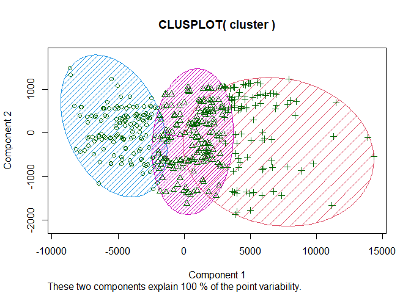

```r
#using K-means to divide participants into groups with parameters total_steps, calories
cluster <- day_merged %>%
  select(total_steps,calories)
#k-means 3 group
model=kmeans(cluster,3)

#plot of clusters
clusplot(cluster,model$cluster,color=T,shade=T)
```

```r
#mean of cluster groups
model$centers
```

```
##   total_steps calories
## 1    3841.818 1976.445
## 2    9209.582 2548.774
## 3   13903.000 2684.427
```

Findings:

- There are three groups: active, average and low activity.
- With an increase in the number of steps, the increase in calories burned decreases. (depends on activity? needs further research)

So we can divide our participants into three group based on activity an calories:

```r
#labeling participants
day_merged <- day_merged %>%
  mutate(group = model$cluster) %>%
  mutate(user_type = case_when(
    group == 1 ~ 'low',
    group == 2 ~ 'average',
    group == 3 ~ 'active',
  ))
```

```r
tabyl(day_merged,user_type)
```

```
##  user_type   n   percent
##     active  96 0.2341463
##    average 177 0.4317073
##        low 137 0.3341463
```

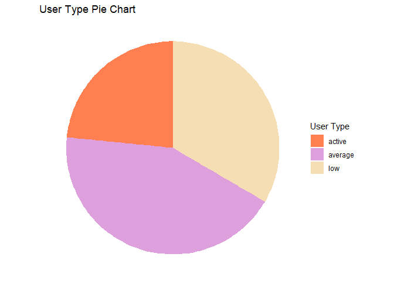

```r
ggplot(tabyl(day_merged,user_type), aes(x="", y=n, fill=user_type))+
  geom_bar(width = 1, stat = "identity")+
  coord_polar("y", start=0)+
  theme(axis.text.x=element_blank())+
  scale_fill_manual(values=c("#FF7F50", "#DDA0DD", "#F5DEB3"))+
  ggtitle("User Type Pie Chart")+
  labs(fill='User Type')+
  theme_void()
```

Well make exploratory analysis using plots. Is like to check some day and day trends in activity. For that I find day part in date.

```r
#add day
day_merged <- day_merged %>%
  mutate(day = wday(activity_date, label=TRUE))

#add day and hour
hour_merged <- hour_merged %>%
  mutate(day = wday(activity_hour, label=TRUE)) %>%
  mutate(hour = hour(activity_hour))
```

```r
#aggregation daily
mean_step_day <- aggregate(total_steps~day+user_type, day_merged, mean)
mean_dist_day <- aggregate(total_distance~day+user_type, day_merged, mean)
mean_sleep_day <- aggregate(total_minutes_asleep~day+user_type, day_merged, mean)
mean_cal_day <- aggregate(calories~day+user_type, day_merged, mean)

#aggregation hourly
mean_step_hour <- aggregate(step_total~hour, hour_merged, mean)
mean_cal_hour <- aggregate(calories~hour, hour_merged, mean)
```

After calculation lets visualize this stats.

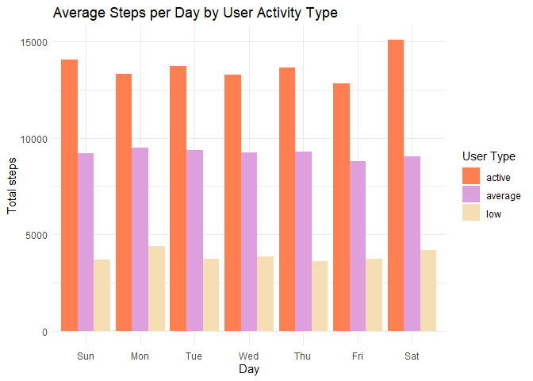

```r
p1<-ggplot(data = mean_step_day, mapping = aes(x = day, y = total_steps,  fill=user_type)) +
  geom_bar(alpha = 1, stat="identity",position=position_dodge())+
  theme_minimal()+
  ggtitle("Average Steps per Day by User Activity Type")+
  labs(fill='User Type')+
  labs(x = "Day", y = "Total steps")

p1+scale_fill_manual(values=c("#FF7F50", "#DDA0DD", "#F5DEB3"))
```

**Tip**

more notification on work days to bust activity

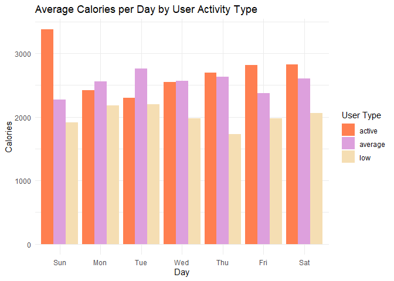

```r
p2<-ggplot(data = mean_cal_day, mapping = aes(x = day, y = calories,  fill=user_type)) +
  geom_bar(alpha = 1, stat="identity",position=position_dodge())+
  theme_minimal()+
  ggtitle("Average Calories per Day by User Activity Type")+
  labs(fill='User Type')+
  labs(x = "Day", y = "Calories")

p2+scale_fill_manual(values=c("#FF7F50", "#DDA0DD", "#F5DEB3"))
```

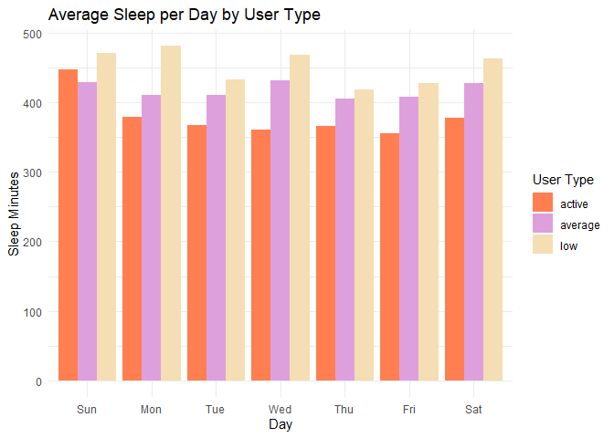

```r
p3<-ggplot(data = mean_sleep_day, mapping = aes(x = day, y = total_minutes_asleep,  fill=user_type)) +
  geom_bar(alpha = 1, stat="identity",position=position_dodge())+
  theme_minimal()+
  ggtitle("Average Sleep per Day by User Type")+
  labs(fill='User Type')+
  labs(x = "Day", y = "Sleep Minutes")

p3+scale_fill_manual(values=c("#FF7F50", "#DDA0DD", "#F5DEB3"))
```

We can clearly see that active people need less sleep than inactive people.

**Tip**

build the challenge for a week to go to bed on alarms and walk at least 9000 steps and evaluate the relationship

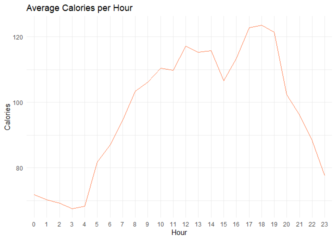

```r
p4<-ggplot(data = mean_cal_hour, mapping = aes(x = as.factor(hour), y = calories, group = 1)) +
  geom_line(col ="#FF7F50", size = .5, linetype = "solid" )+
  theme_minimal()+
  ggtitle("Average Calories per Hour")+
  labs(x = "Hour", y = "Calories")

p4
```

**Tip**

smart notification in the morning and in the evening - not to use transport, also in the luncn time use notification to go to the park.

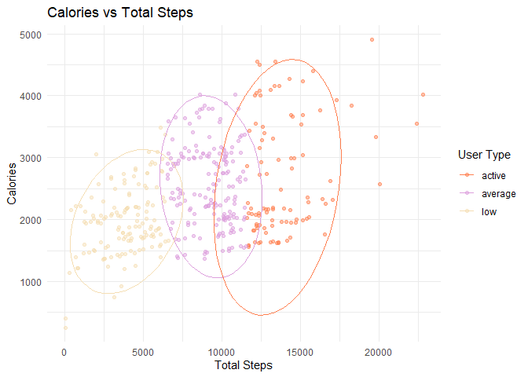

```r
#check correlation
p5 <- ggplot(day_merged, aes(y=calories, x=total_steps, color = user_type)) +
  geom_point(alpha = 0.5)+
  theme_minimal()+
  ggtitle("Calories vs Total Steps")+
  labs(color='User Type')+
  labs(x = "Total Steps", y = "Calories")+
  stat_ellipse()


p5 + scale_color_manual(values=c("#FF7F50", "#DDA0DD", "#F5DEB3"))
```

We see that active users spend calories by walking more than the norm, however, users with average activity spend same calories by walking the norm of steps.

**Tip**

inspirational advert to provide that it is enough to be only average to be healthy to bust our low activity users

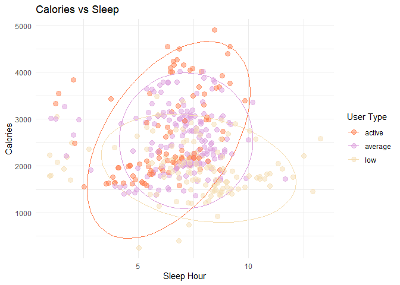

```r
#check correlation
p6 <- ggplot(day_merged, aes(y=calories, x=total_minutes_asleep/60, color = user_type)) +
  geom_point(alpha = 0.5, size = 3)+
  theme_minimal()+
  ggtitle("Calories vs Sleep")+
  labs(color='User Type')+
  labs(x = "Sleep Hour", y = "Calories")+
  stat_ellipse()



p6 + scale_color_manual(values=c("#FF7F50", "#DDA0DD", "#F5DEB3"))
```

There is a connection between activity and sleep, but it is not obvious in such a small sample.

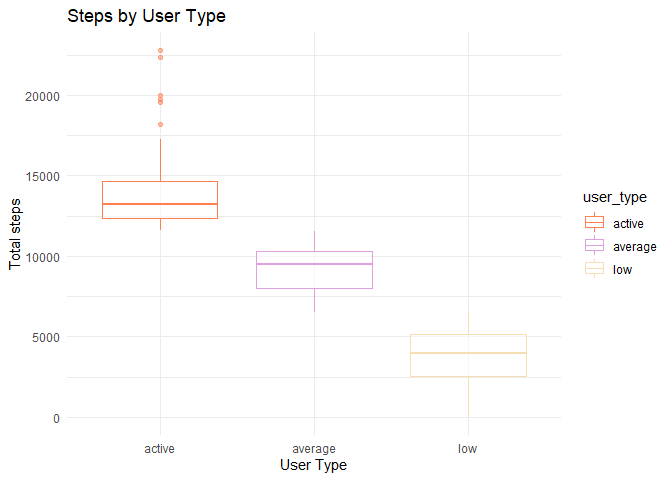

```r
#daily step by user type
p7<-ggplot(data = day_merged, mapping = aes(x = user_type, y = total_steps, color = user_type)) +
  geom_boxplot(alpha = 0.5)+
  theme_minimal()+
  ggtitle("Steps by User Type")+
  labs(fill='User Type')+
  labs(x = "User Type", y = "Total steps")

p7+scale_color_manual(values=c("#FF7F50", "#DDA0DD", "#F5DEB3"))
```

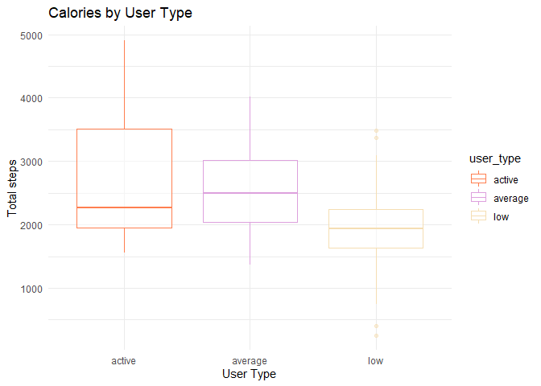

```r
#daily step by user type
p8<-ggplot(data = day_merged, mapping = aes(x = user_type, y = calories, color = user_type)) +
  geom_boxplot(alpha = 0.5)+
  theme_minimal()+
  ggtitle("Calories by User Type")+
  labs(fill='User Type')+
  labs(x = "User Type", y = "Total steps")

p8+scale_color_manual(values=c("#FF7F50", "#DDA0DD", "#F5DEB3"))
```

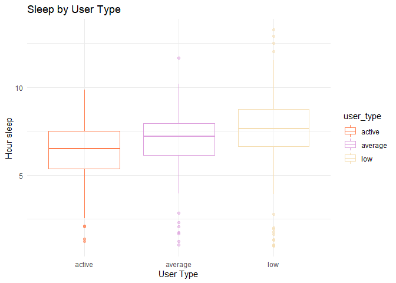

```r
#daily sleep by user type
p9<-ggplot(data = day_merged, mapping = aes(x = user_type, y = total_minutes_asleep/60, color = user_type)) +
  geom_boxplot(alpha = 0.5)+
  theme_minimal()+
  ggtitle("Sleep by User Type")+
  labs(fill='User Type')+
  labs(x = "User Type", y = "Hour sleep")

p9+scale_color_manual(values=c("#FF7F50", "#DDA0DD", "#F5DEB3"))
```

#### 6.High-level recommendations based on analysis

- Inspirational advert to provide that it is enough to be only average to be healthy to bust our low activity users
- Smart notification in the morning and in the evening - not to use transport, also in the luncn time use notification to go to the park.
- Build the challenge for a week to go to bed on alarms and walk at least 9000 steps and evaluate the relationship
- More notification on work days to bust activity